# PA_ggeneral

Gabriel General

20-02-2021 00:31

# Loading and preprocessing the data

### 1. Load the data (i.e. read.csv())

```r
DataFileName <- "./activity.zip"
dataDir <- "./data"


if (!file.exists(dataDir)) {
  dir.create(dataDir)
  unzip(zipfile = DataFileName, exdir = dataDir)
}


data <- read.csv("./data/activity.csv", header = TRUE, sep = ",")
data$date <- as.Date(data$date, format = "%Y-%m-%d")
data1 <- na.omit(data)
#data1$date <- as.Date(data1$date, format = "%Y-%m-%d")
```

### 2. Process/transform the data (if necessary) into a format suitable for your analysis

```r
total <- as.numeric(nrow(data))
total_step <- aggregate(steps ~ date, data = data, sum, na.rm = TRUE)
valid <- as.numeric(nrow(data1))
total_valid <- aggregate(steps ~ date, data = data1, sum, na.rm = TRUE)
percent <- trunc((total - valid)*100/total)
steps <- total_step$steps
```

There are **13**% of missing values ommited.

# What is mean total number of steps taken per day?

### 1. Make a histogram of the total number of steps taken each day

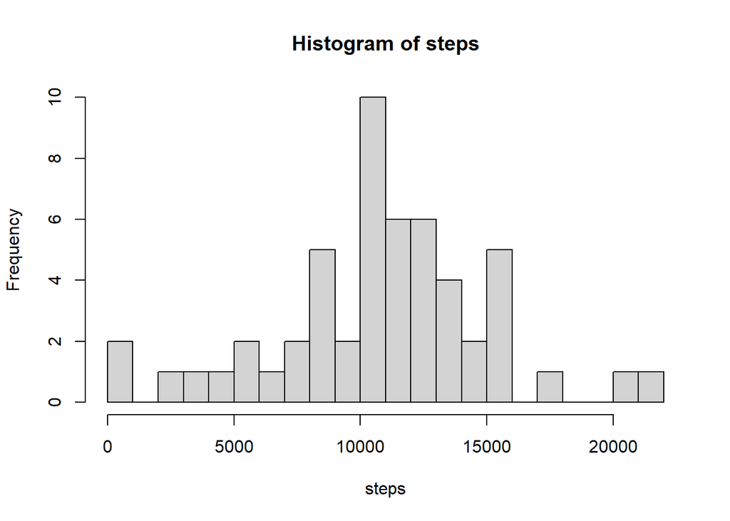

```r
hist(steps, breaks = 30)
```

### Summary of steps

```r
print(summary(data1$steps))
```

```
   Min. 1st Qu.  Median    Mean 3rd Qu.    Max.
   0.00    0.00    0.00   37.38   12.00  806.00
```

### Mean and median of steps by day

```r
library(xtable)
library(dplyr)
meanPerDay <- aggregate(steps ~ date, data1, mean)
names(meanPerDay)[2] <- "meanSteps"
medianPerDay <- aggregate(steps ~ date, data1, median)
names(medianPerDay)[2] <- "medianSteps"
summarySteps <- merge(meanPerDay,medianPerDay, all = TRUE)
tblMeanPerDay <- xtable(summarySteps)
tblMeanPerDay$date <- as.character(tblMeanPerDay$date)
print(tblMeanPerDay,type = "html")
```

|  | date | meanSteps | medianSteps |
| --- | --- | --- | --- |
| 1 | 2012-10-02 | 0.44 | 0.00 |
| 2 | 2012-10-03 | 39.42 | 0.00 |
| 3 | 2012-10-04 | 42.07 | 0.00 |
| 4 | 2012-10-05 | 46.16 | 0.00 |
| 5 | 2012-10-06 | 53.54 | 0.00 |
| 6 | 2012-10-07 | 38.25 | 0.00 |
| 7 | 2012-10-09 | 44.48 | 0.00 |
| 8 | 2012-10-10 | 34.38 | 0.00 |
| 9 | 2012-10-11 | 35.78 | 0.00 |
| 10 | 2012-10-12 | 60.35 | 0.00 |
| 11 | 2012-10-13 | 43.15 | 0.00 |
| 12 | 2012-10-14 | 52.42 | 0.00 |
| 13 | 2012-10-15 | 35.20 | 0.00 |
| 14 | 2012-10-16 | 52.38 | 0.00 |
| 15 | 2012-10-17 | 46.71 | 0.00 |
| 16 | 2012-10-18 | 34.92 | 0.00 |
| 17 | 2012-10-19 | 41.07 | 0.00 |
| 18 | 2012-10-20 | 36.09 | 0.00 |
| 19 | 2012-10-21 | 30.63 | 0.00 |
| 20 | 2012-10-22 | 46.74 | 0.00 |
| 21 | 2012-10-23 | 30.97 | 0.00 |
| 22 | 2012-10-24 | 29.01 | 0.00 |
| 23 | 2012-10-25 | 8.65 | 0.00 |
| 24 | 2012-10-26 | 23.53 | 0.00 |
| 25 | 2012-10-27 | 35.14 | 0.00 |
| 26 | 2012-10-28 | 39.78 | 0.00 |
| 27 | 2012-10-29 | 17.42 | 0.00 |
| 28 | 2012-10-30 | 34.09 | 0.00 |
| 29 | 2012-10-31 | 53.52 | 0.00 |
| 30 | 2012-11-02 | 36.81 | 0.00 |
| 31 | 2012-11-03 | 36.70 | 0.00 |
| 32 | 2012-11-05 | 36.25 | 0.00 |
| 33 | 2012-11-06 | 28.94 | 0.00 |
| 34 | 2012-11-07 | 44.73 | 0.00 |
| 35 | 2012-11-08 | 11.18 | 0.00 |
| 36 | 2012-11-11 | 43.78 | 0.00 |
| 37 | 2012-11-12 | 37.38 | 0.00 |
| 38 | 2012-11-13 | 25.47 | 0.00 |
| 39 | 2012-11-15 | 0.14 | 0.00 |
| 40 | 2012-11-16 | 18.89 | 0.00 |
| 41 | 2012-11-17 | 49.79 | 0.00 |
| 42 | 2012-11-18 | 52.47 | 0.00 |
| 43 | 2012-11-19 | 30.70 | 0.00 |
| 44 | 2012-11-20 | 15.53 | 0.00 |
| 45 | 2012-11-21 | 44.40 | 0.00 |
| 46 | 2012-11-22 | 70.93 | 0.00 |
| 47 | 2012-11-23 | 73.59 | 0.00 |
| 48 | 2012-11-24 | 50.27 | 0.00 |
| 49 | 2012-11-25 | 41.09 | 0.00 |
| 50 | 2012-11-26 | 38.76 | 0.00 |
| 51 | 2012-11-27 | 47.38 | 0.00 |
| 52 | 2012-11-28 | 35.36 | 0.00 |
| 53 | 2012-11-29 | 24.47 | 0.00 |

```r
promedio <- trunc(mean(total_step$steps))
mediana <- median(total_step$steps)
```

The median of total number of steps taken is **10765**

# What is the average daily activity pattern?

### 1. Make a time series plot (i.e. type = “l”) of the 5-minute interval (x-axis) and the average number of steps taken, averaged across all days (y-axis)

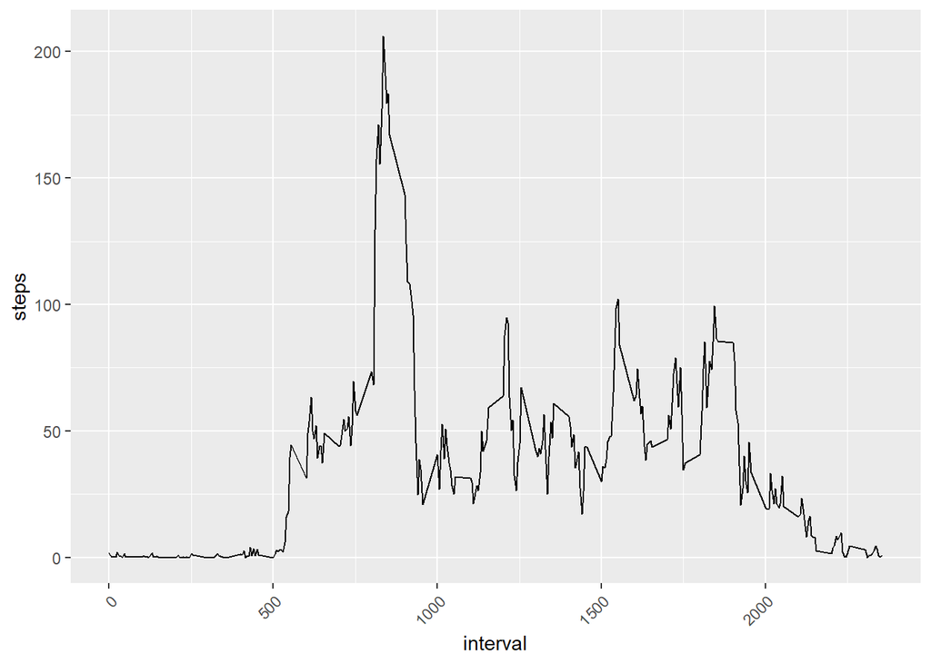

```r
library(ggplot2)
library(dplyr)


meanStepInterval <- aggregate(steps ~ interval, data1, mean)

ggplot(meanStepInterval, aes(interval, steps)) +
  geom_line() +
  theme(axis.text.x = element_text(angle=45, hjust=1, vjust = 1))
```

```r
maxStepInterval <- meanStepInterval[which.max(meanStepInterval$steps),]
maxInterval <- maxStepInterval$interval
maxStep <- maxStepInterval$steps
```

### 2. Which 5-minute interval, on average across all the days in the dataset,contains the maximum number of steps?

A: The 5-minute interval that contains the maximum number of steps is **835** with an average of **206.1698113** steps

# Imputing missing values

Note that there are a number of days/intervals where there are missing values (coded as NA). The presence of missing days may introduce bias into some calculations or summaries of the data.

### 1. Calculate and report the total number of missing values in the dataset (i.e. the total number of rows with NAs)

```r
total <- as.numeric(nrow(data))
valid <- as.numeric(nrow(data1))
missingValues <- total - valid
percent <- trunc((total - valid)*100/total)
steps <- data1$steps
```

There are **2304** missing values, a **13**% of total values.

### 2. Devise a strategy for filling in all of the missing values in the dataset. The strategy does not need to be sophisticated. For example, you could usethe mean/median for that day, or the mean for that 5-minute interval, etc.

We’ll use the mean for 5 - minutes interval to fill the missing values in dataset

```r
dato3 <- data

prom_step <- aggregate(steps ~ interval, data, mean, na.rm = TRUE)
```

### 3. Create a new dataset that is equal to the original dataset but with the missing data filled in.

```r
for (i in prom_step$interval) {
    dato3[dato3$interval == i & is.na(dato3$steps), ]$steps <-
        prom_step$steps[prom_step$interval == i]
}
```

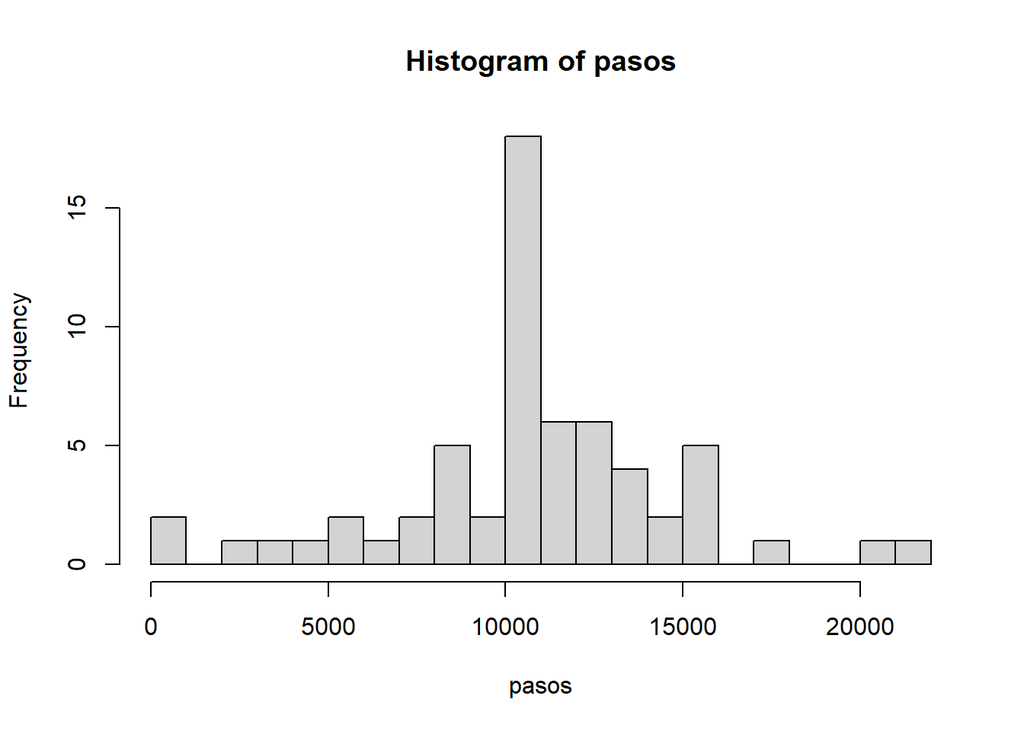

```r
total_num_step <- aggregate(steps ~ date, dato3,sum,na.rm = TRUE)

pasos <- total_num_step$steps

hist(pasos, breaks = 30)
```

# Are there differences in activity patterns between weekdays and weekends? For this part the weekdays() function may be of some help here. Use the dataset with the filled-in missing values for this part.

### 1. Create a new factor variable in the dataset with two levels – “weekday” and “weekend” indicating whether a given date is a weekday or weekend day.

```r
dato4 <- dato3

dato4$date <- as.Date(dato4$date)
#create a vector of weekdays
weekdays1 <- c('lunes', 'martes', 'miercoles', 'jueves', 'viernes')
#Use `%in%` and `weekdays` to create a logical vector
#convert to `factor` and specify the `levels/labels`
dato4$wday <- factor((weekdays(dato4$date) %in% weekdays1), levels=c(FALSE, TRUE),labels=c('weekend', 'weekday'))
```

### 2. Make a panel plot containing a time series plot (i.e. type = “l”) of the 5-minute interval (x-axis) and the average number of steps taken, averaged across all weekday days or weekend days (y-axis). The plot should look something like the following, which was creating using simulated data:

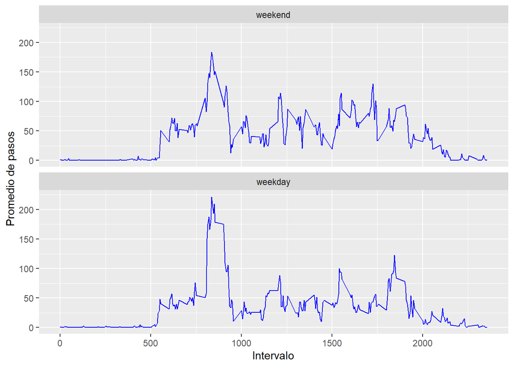

```r
finde <- aggregate(steps ~ wday + interval, mean,data = dato4)


#str(finde)

ggplot(finde,
       aes(x = interval, y = steps)) +
  xlab("Intervalo") + ylab("Promedio de pasos") +
  geom_line(color = "blue") +
  facet_wrap (~wday, ncol = 1)
```